# Relatorio

Joon Hyuk Kim, Ramon Dantas de Jesus

14 de novembro de 2018

## ANOVA

Nesta analise ANOVA, tentaremos ver se existe uma relação entre o ano de construção da ponte (ERECTED), e o material da qual ela foi construída:

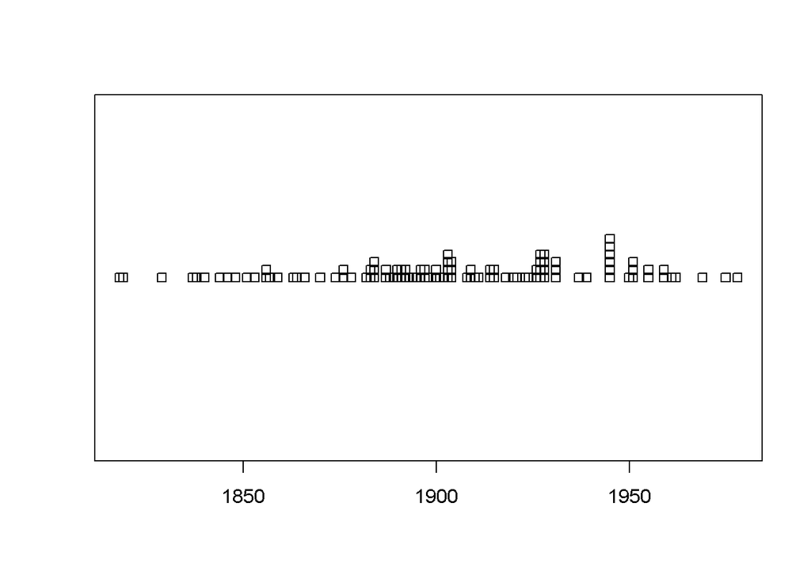

```r
# Realizar ANOVA entre ano de criação da ponte (ERECTED) e material.
data <- read.csv("data.txt", na.strings="?")
dataSubset <- subset(data, select = c("ERECTED", "MATERIAL"))
dataSubset <- dataSubset[complete.cases(dataSubset), ]
n <- nrow(dataSubset)

xlim <- c(min(dataSubset$ERECTED), max(dataSubset$ERECTED))
stripchart(dataSubset$ERECTED, method="stack", xlim=xlim)
```

```r
# Primeiro, sem nenhum fator, calcular a soma de quadrados.
mediaAno <- mean(dataSubset$ERECTED)
somaTotalQuadrados <- sum((dataSubset$ERECTED - mediaAno) ^ 2)

# Depois, levar a consideração o fator ERECTED.
dadosWood <- subset(dataSubset, MATERIAL == "WOOD")
dadosIron <- subset(dataSubset, MATERIAL == "IRON")
dadosSteel <- subset(dataSubset, MATERIAL == "STEEL")
```

Para ter uma ideia de se o material tem alguma relação com o ano de construção, primeiro vejamos a distribuição dos materiais pelos anos. Os gráficos representam as pontos de madeira, ferro, e aço, respectivamente:

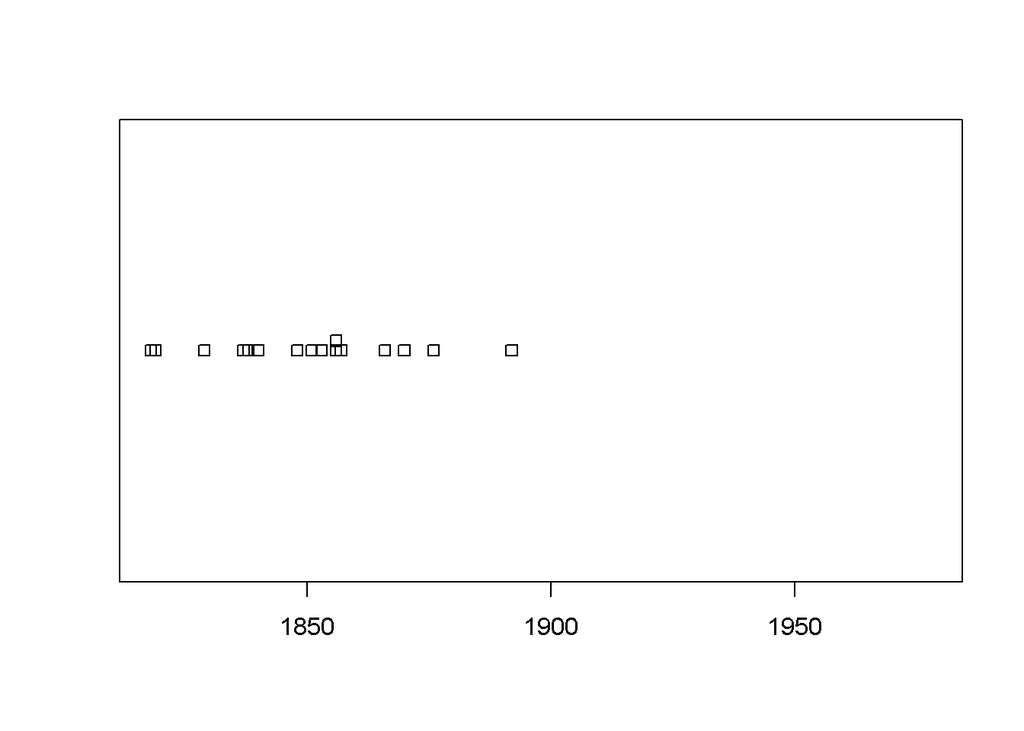

```r
stripchart(dadosWood$ERECTED, method="stack", xlim=xlim)
```

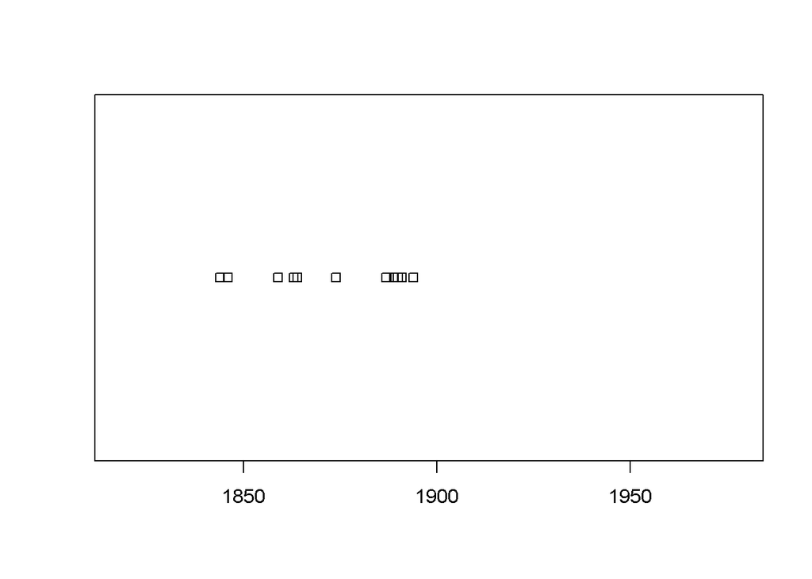

```r
stripchart(dadosIron$ERECTED, method="stack", xlim=xlim)
```

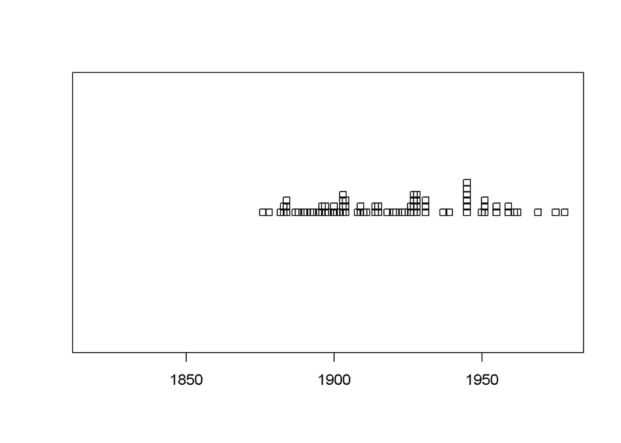

```r
stripchart(dadosSteel$ERECTED, method="stack", xlim=xlim)
```

Aparenta existir uma relação, então vamos fazer a tabela ANOVA, considerando este fator:

```r
mediaWood <- mean(dadosWood$ERECTED)
mediaIron <- mean(dadosIron$ERECTED)
mediaSteel <- mean(dadosSteel$ERECTED)

sqWood <- sum((dadosWood$ERECTED - mediaWood)^2)
sqIron <- sum((dadosIron$ERECTED - mediaIron)^2)
sqSteel <- sum((dadosSteel$ERECTED - mediaSteel)^2)

somaQuadradosResiduais <- sqWood + sqIron + sqSteel
somaQuadradosEntre <- somaTotalQuadrados - somaQuadradosResiduais

quadradoMedioTotal <- somaTotalQuadrados / (n - 1)
quadradoMedioEntre <- somaQuadradosEntre / 2
quadradoMedioDentro <- somaQuadradosResiduais / (n - 2 - 1)

# Montar a tabela ANOVA
tabelaAnova <- data.frame(
  liberdade = c(2, n - 2 - 1, n - 1),
  SQ = c(somaQuadradosEntre, somaQuadradosResiduais, somaTotalQuadrados),
  QM = c(quadradoMedioEntre, quadradoMedioDentro, quadradoMedioTotal),
  F = c(quadradoMedioEntre / quadradoMedioDentro, "", "")
)

rownames(tabelaAnova) <- c("Entre", "Dentro", "Total")

library(knitr)
kable(tabelaAnova, caption = "Tabela ANOVA")
```

Tabela ANOVA

|  | liberdade | SQ | QM | F |
| --- | --- | --- | --- | --- |
| Entre | 2 | 74417.61 | 37208.804 | 63.0146112042655 |
| Dentro | 103 | 60819.34 | 590.479 |  |
| Total | 105 | 135236.94 | 1287.971 |  |

```r
print(paste("Valor de f para 2,", n - 2 - 1, ", com 95% de confiança:", qf(0.95, 2, n - 2 - 1)))
```

[1] “Valor de f para 2, 103 , com 95% de confiança: 3.08457678488047”

```r
print(paste("Como este valor é menor que", quadradoMedioEntre / quadradoMedioDentro, "rejeitamos a hipótese nula."))
```

[1] “Como este valor é menor que 63.0146112042655 rejeitamos a hipótese nula.”

Tentamos fazer essa análise para todo par de variáveis numérica-nominal, e testamos a significância daquela relação baseados nos seus *p-values*:

```r
significance <- function(x) {
  if (x <= 0.001) {
    "***"
  } else if (x <= 0.01) {
    "**"
  } else if (x <= 0.05) {
    "*"
  } else if (x <= 0.1) {
    "."
  } else {
    " "
  }
}

data <- read.csv("data.txt", na.strings="?")

numerical <- c("ERECTED", "LENGTH", "LANES")
nominal <- c("PURPOSE", "CLEAR.G", "T.OR.D", "MATERIAL", "SPAN", "REL.L", "TYPE")

pValuesMatrix <- matrix(0, nrow = length(nominal), ncol = length(numerical))
rownames(pValuesMatrix) <- nominal
colnames(pValuesMatrix) <- numerical

significanceMatrix <- matrix(0, nrow = length(nominal), ncol = length(numerical))
rownames(significanceMatrix) <- nominal
colnames(significanceMatrix) <- numerical

for (numVar in numerical) {
  for (nomVar in nominal) {
    form <- as.formula(paste(numVar, "~", paste0("`", nomVar, "`")))
    dataSubset <- subset(data, select = c(numVar, nomVar))
    dataSubset <- dataSubset[complete.cases(dataSubset), ]

    analysis <- aov(form, data = dataSubset)

    pVal <- summary(analysis)[[1]][["Pr(>F)"]][[1]]
    pValuesMatrix[nomVar, numVar] <- pVal
    significanceMatrix[nomVar, numVar] <- significance(pVal)
  }
}

library(knitr)
kable(pValuesMatrix, caption = "Matriz de p-values")
```

Matriz de p-values

|  | ERECTED | LENGTH | LANES |
| --- | --- | --- | --- |
| PURPOSE | 0.0054929 | 0.0601870 | 0.0000314 |
| CLEAR.G | 0.0000000 | 0.1980417 | 0.0117803 |
| T.OR.D | 0.0101995 | 0.0017112 | 0.0770901 |
| MATERIAL | 0.0000000 | 0.0213171 | 0.0008465 |
| SPAN | 0.0000000 | 0.0051145 | 0.0177725 |
| REL.L | 0.0000000 | 0.0484276 | 0.0009640 |
| TYPE | 0.0000000 | 0.0612771 | 0.0000000 |

```r
kable(significanceMatrix, caption = "Matriz de significancia.")
```

Matriz de significancia.

|  | ERECTED | LENGTH | LANES |
| --- | --- | --- | --- |
| PURPOSE | ** | . | *** |
| CLEAR.G | *** |  | * |
| T.OR.D | * | ** | . |
| MATERIAL | *** | * | *** |
| SPAN | *** | ** | * |
| REL.L | *** | * | *** |
| TYPE | *** | . | *** |

A legenda para a matriz de significância é como segue: `0 ‘***’ 0.001 ‘**’ 0.01 ‘*’ 0.05 ‘.’ 0.1 ‘ ’ 1`

## Análise de regressão simples

Nos nossos dados, existem 3 variáveis numéricas: ERECTED (ano de construção), LENGTH (tamanho da ponte), e LANES (número de pistas). Assim sendo, tentaremos ver se existe alguma relação linear entre elas, primeiro olhando os gráficos, e depois criando um modelo de regressão linear.

```r
# Tentar realizar regressão simples em cima das variaveis numéricas
data <- read.csv("data.txt", na.strings="?")
dataELength <- subset(data, select = c("ERECTED", "LENGTH"))
dataELength <- dataELength[complete.cases(dataELength), ]

dataELanes <- subset(data, select = c("ERECTED", "LANES"))
dataELanes <- dataELanes[complete.cases(dataELanes), ]

dataLengthLanes <- subset(data, select = c("LENGTH", "LANES"))
dataLengthLanes <- dataLengthLanes[complete.cases(dataLengthLanes), ]
```

Após ler os dados, montaremos gráficos ERECTED x LENGTH, ERECTED x LANES e LENGTH x LANES, respectivamente:

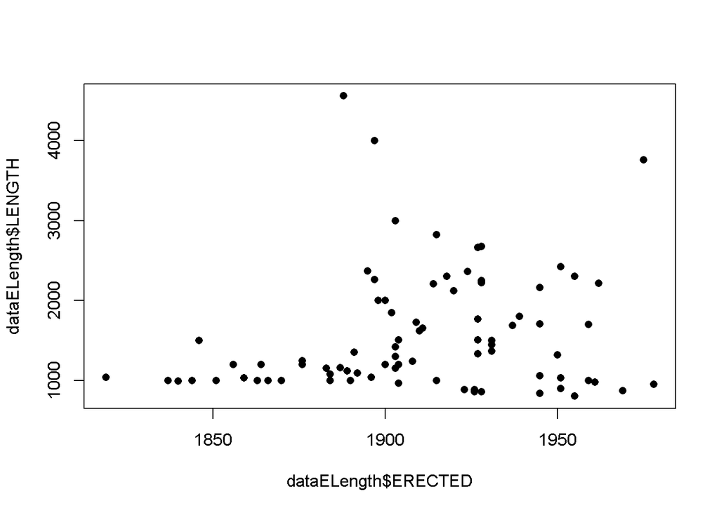

```r
plot(dataELength$ERECTED, dataELength$LENGTH, pch = 16)
```

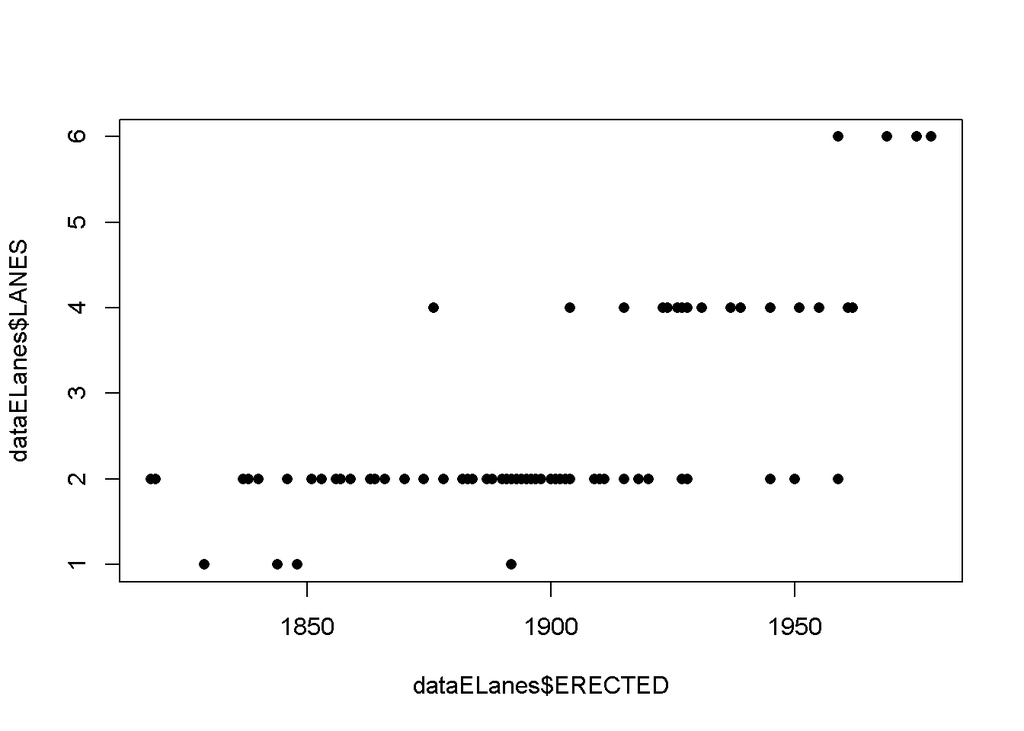

```r
plot(dataELanes$ERECTED, dataELanes$LANES, pch = 16)
```

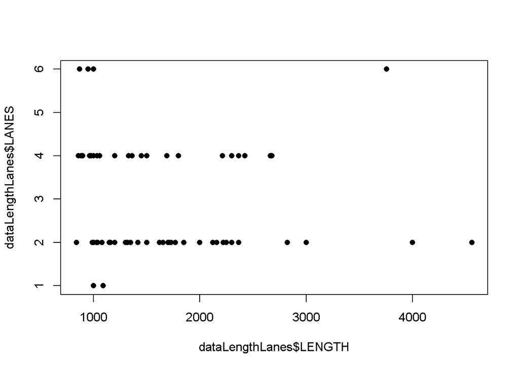

```r
plot(dataLengthLanes$LENGTH, dataLengthLanes$LANES, pch = 16)
```

```r
# Escolhemos a relação LENGTH em função de ERECTED
modeloLinear <- lm(LENGTH ~ ERECTED, data = dataELength)
summary(modeloLinear)
```

```
##
## Call:
## lm(formula = LENGTH ~ ERECTED, data = dataELength)
##
## Residuals:
##    Min     1Q Median     3Q    Max
## -938.6 -403.0 -198.7  443.0 3077.4
##
## Coefficients:
##              Estimate Std. Error t value Pr(>|t|)
## (Intercept) -5903.164   4544.167  -1.299    0.198
## ERECTED         3.911      2.378   1.644    0.104
##
## Residual standard error: 739.7 on 79 degrees of freedom
## Multiple R-squared:  0.03309,    Adjusted R-squared:  0.02085
## F-statistic: 2.704 on 1 and 79 DF,  p-value: 0.1041
```

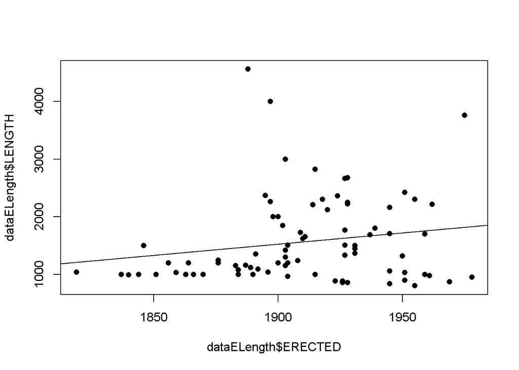

```r
plot(dataELength$ERECTED, dataELength$LENGTH, pch = 16)
abline(modeloLinear)
```

No final, ao analisarmos o gráfico gerado pela regressão linear, vemos que existem pontos que estão muito longes da linha, e que, no geral, eles não se aproximam tanto dela. Embora pareça haver uma tendência de aumento de tamanho ao passar dos anos, este modelo não prevê muito bem.

## Análise de Regressão Múltipla

Das três variáveis numéricas, não aparenta existir informação o bastante para justificar uma regressão múltipla. Visualmente, é possível ver isto pelo gráfico gerado abaixo.

```r
library(rgl)

data <- read.csv("data.txt", na.strings="?")
dataSubset <- subset(data, select = c("ERECTED", "LENGTH", "LANES"))
dataSubset <- dataSubset[complete.cases(dataSubset), ]

plot3d(dataSubset)
```

[interactive chart not shown]

De qualquer maneira, vamos tentar adicionar um outro fator ao modelo linear criado anteriormente (LENGTH em função de ERECTED), adicionando a variável LANES ao modelo:

```r
# Vamos tentar partir do modelo da regressão simples, e tentar adicionar uma outra variável (LANES).
modeloLinear <- lm(LENGTH ~ ERECTED, data = dataSubset)
modeloMultipla <- lm(LENGTH ~ ERECTED + LANES, data = dataSubset)
kable(anova(modeloLinear, modeloMultipla), caption = "Tabela ANOVA, comparando os modelos LENGTH ~ ERECTED e LENGTH ~ ERECTED + LANES")
```

Tabela ANOVA, comparando os modelos LENGTH ~ ERECTED e LENGTH ~ ERECTED + LANES

| Res.Df | RSS | Df | Sum of Sq | F | Pr(>F) |
| --- | --- | --- | --- | --- | --- |
| 70 | 40924285 | NA | NA | NA | NA |
| 69 | 39084949 | 1 | 1839336 | 3.247137 | 0.0759164 |

## Análise de Componentes Principais

```r
library(psych)
data <- read.csv("data.txt", na.strings="?")
attach(data)

#definir variaveis
X<- subset(data, select = c("LOCATION","ERECTED","LENGTH","LANES"))
X<- X[complete.cases(X), ]

#descricoes estatisticas
summary(X)
```

```
##     LOCATION        ERECTED         LENGTH         LANES
##  Min.   : 1.00   Min.   :1819   Min.   : 840   Min.   :1.000
##  1st Qu.:14.75   1st Qu.:1890   1st Qu.:1000   1st Qu.:2.000
##  Median :27.00   Median :1913   Median :1310   Median :2.000
##  Mean   :25.15   Mean   :1910   Mean   :1582   Mean   :2.833
##  3rd Qu.:35.25   3rd Qu.:1932   3rd Qu.:2000   3rd Qu.:4.000
##  Max.   :49.00   Max.   :1978   Max.   :4558   Max.   :6.000
```

```r
#matriz de correlacao
cor(X)
```

```
##            LOCATION   ERECTED      LENGTH       LANES
## LOCATION  1.0000000 0.1415547  0.28318999 -0.12462973
## ERECTED   0.1415547 1.0000000  0.19907476  0.65071814
## LENGTH    0.2831900 0.1990748  1.00000000 -0.02821361
## LANES    -0.1246297 0.6507181 -0.02821361  1.00000000
```

As variáveis utilizadas para essa análise foram a localização, o ano de lançamento, a distância total e o número de linhas.

```r
#PCA
pca1 <- princomp(X, scores=TRUE, cor=TRUE)

#descricoes estatisticas do PCA
summary(pca1)
```

```
## Importance of components:
##                           Comp.1    Comp.2    Comp.3     Comp.4
## Standard deviation     1.2968019 1.1490669 0.8431793 0.53572262
## Proportion of Variance 0.4204238 0.3300887 0.1777378 0.07174968
## Cumulative Proportion  0.4204238 0.7505125 0.9282503 1.00000000
```

Realizada a função de montar os componentes principais, podemos observar que os dois primeiros componentes são capazes de representarem, juntos, aproximadamente 75% dos dados avaliados, o que, em teoria, é grande o suficiente para se realizar uma análise dos mesmos.

```r
#Componentes Principais
loadings(pca1)
```

```
##
## Loadings:
##          Comp.1 Comp.2 Comp.3 Comp.4
## LOCATION  0.127  0.690  0.684  0.200
## ERECTED   0.713               -0.696
## LENGTH    0.234  0.633 -0.724  0.142
## LANES     0.648 -0.350         0.675
##
##                Comp.1 Comp.2 Comp.3 Comp.4
## SS loadings      1.00   1.00   1.00   1.00
## Proportion Var   0.25   0.25   0.25   0.25
## Cumulative Var   0.25   0.50   0.75   1.00
```

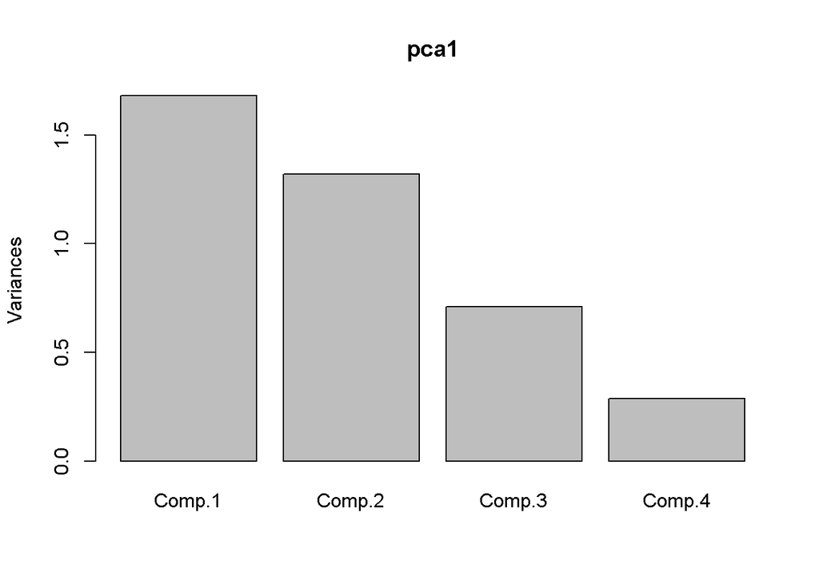

```r
#Imprimir os autovalores
plot(pca1)
```

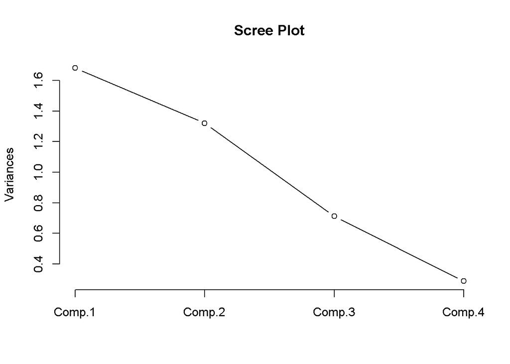

```r
screeplot(pca1, type="line", main="Scree Plot")
```

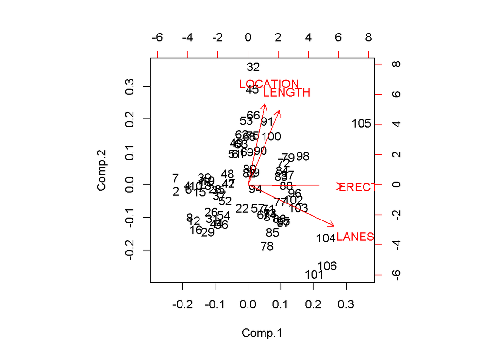

```r
#Imprimir os escores
biplot(pca1)
```

```r
#Rotacao VARIMAX
pca2 <- principal(X, nfactors = 2, scores=TRUE)
summary(pca2)
```

```
##
## Factor analysis with Call: principal(r = X, nfactors = 2, scores = TRUE)
##
## Test of the hypothesis that 2 factors are sufficient.
## The degrees of freedom for the model is -1  and the objective function was  0.6
## The number of observations was  72  with Chi Square =  40.54  with prob <  NA
##
## The root mean square of the residuals (RMSA) is  0.16
```

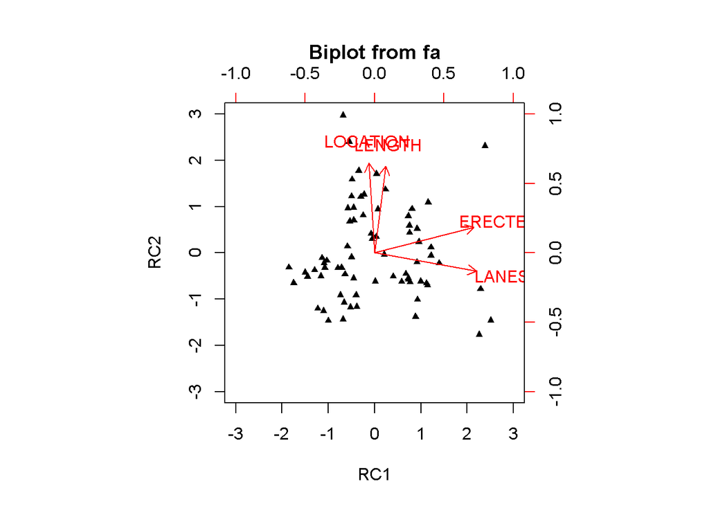

```r
biplot(pca2)
```

## Análise Fatorial

```r
#Inicializacao dos dados

data <- read.csv("data.txt", na.strings="?")
dataSubset <- subset(data, select = c("ERECTED", "LENGTH", "LANES"))
dados <- dataSubset[complete.cases(dataSubset), ]
summary(dados)
```

```
##     ERECTED         LENGTH         LANES
##  Min.   :1819   Min.   : 840   Min.   :1.000
##  1st Qu.:1890   1st Qu.:1000   1st Qu.:2.000
##  Median :1913   Median :1310   Median :2.000
##  Mean   :1910   Mean   :1582   Mean   :2.833
##  3rd Qu.:1932   3rd Qu.:2000   3rd Qu.:4.000
##  Max.   :1978   Max.   :4558   Max.   :6.000
```

```r
#Preparacao da matriz de correlacao
matriz_correlacao <- cor(dados)
print(matriz_correlacao,digits=3)
```

```
##         ERECTED  LENGTH   LANES
## ERECTED   1.000  0.1991  0.6507
## LENGTH    0.199  1.0000 -0.0282
## LANES     0.651 -0.0282  1.0000
```

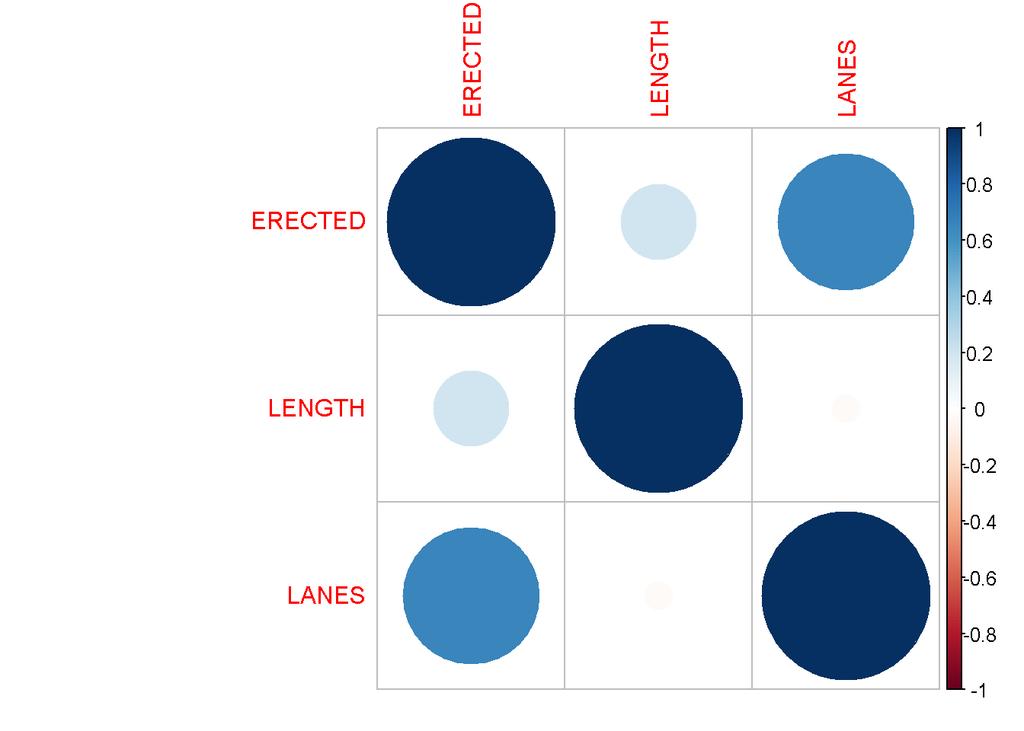

```r
#Corgrama
library(corrplot)
corrplot(matriz_correlacao)
```

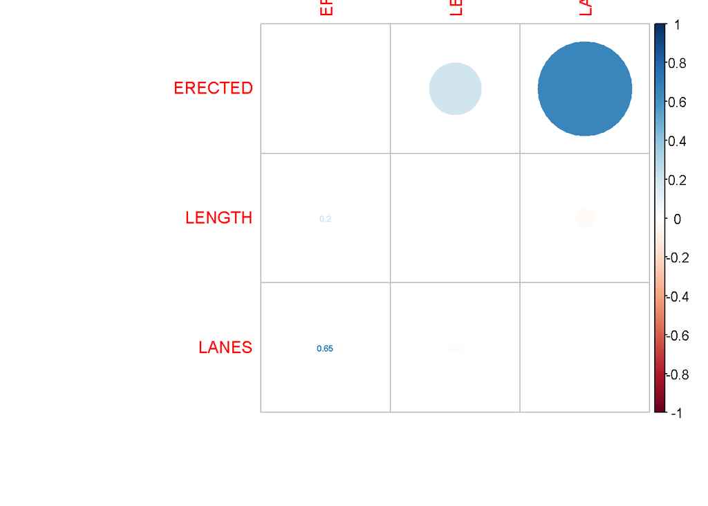

```r
corrplot.mixed(matriz_correlacao, lower = "number", upper = "circle", number.cex = 0.5, tl.pos = "lt")
```

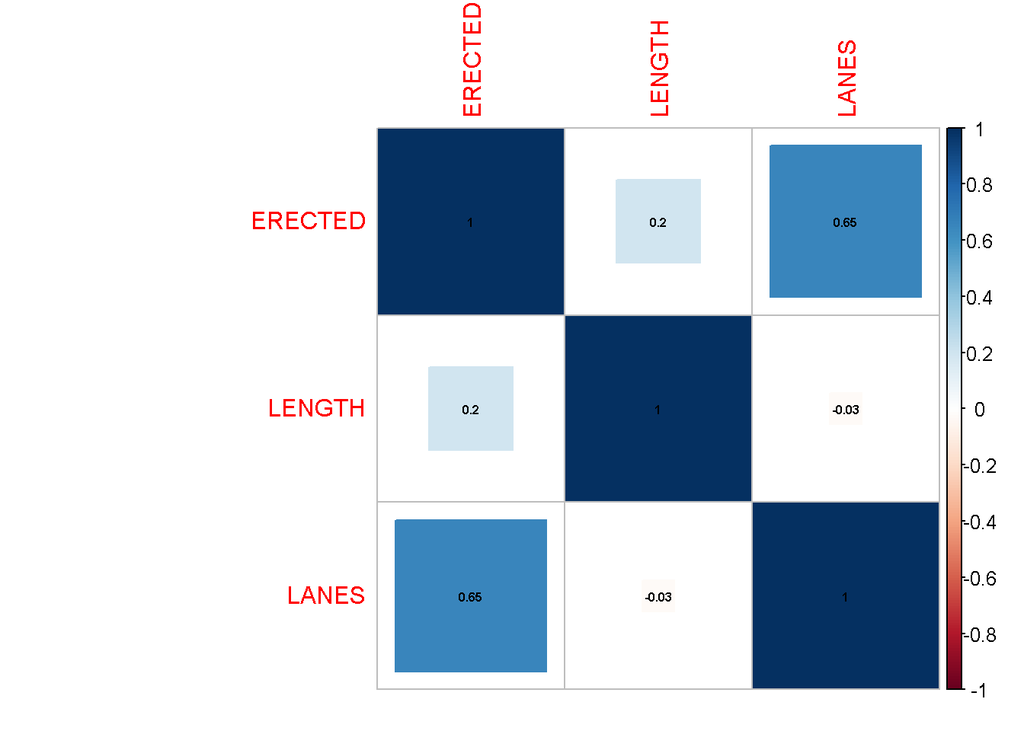

```r
corrplot(matriz_correlacao, method = "square", number.cex = 0.5, addCoef.col = "black")
```

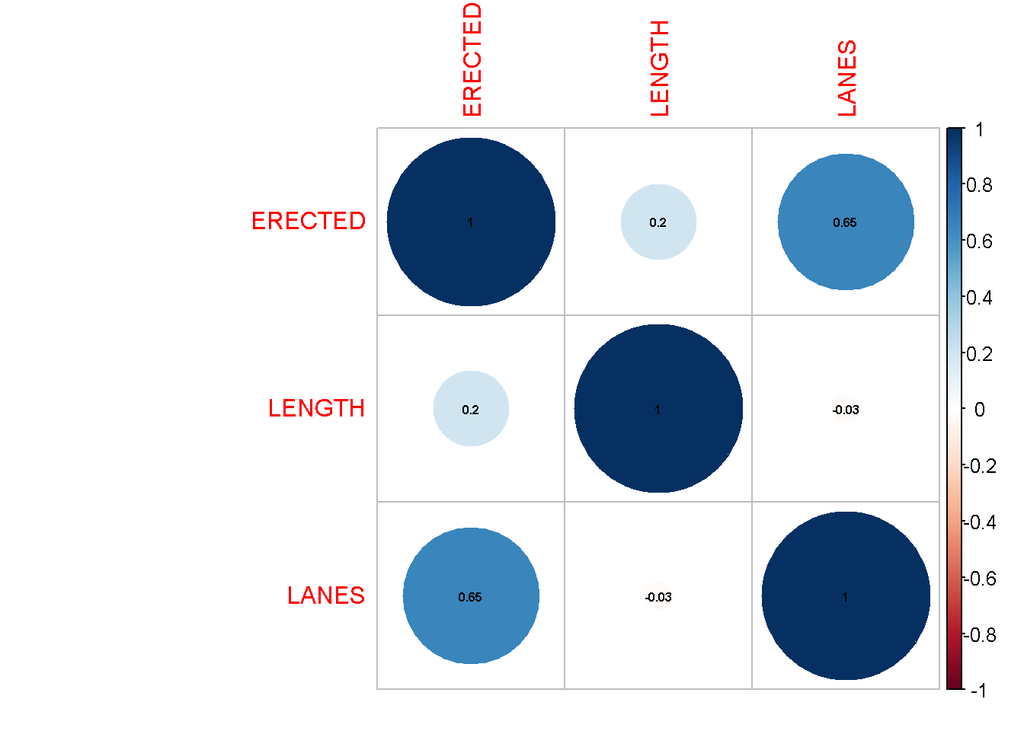

```r
corrplot(matriz_correlacao, method = "circle", number.cex = 0.5, addCoef.col = "black")
```

Como podemos observar, entre as variáveis númericas do banco de dados, a variável ano de lançamento (ERECTED) é a variável que mais influencia sobre as outras variáveis, como concluído nas análises anteriores. Para garantir que essa análise está, de fato, bem calculada, realizamos o teste de esfericidade de Bartlett e o teste KMO

```r
#Teste de esfericidade de Bartlett

Bartlett.sphericity.test <- function(x)
{
  method <- "Teste de esfericidade de Bartlett"
  data.name <- deparse(substitute(x))
  x <- subset(x, complete.cases(x)) # Omitindo valores faltantes
  n <- nrow(x)
  p <- ncol(x)
  chisq <- (1-n+(2*p+5)/6)*log(det(cor(x)))
  df <- p*(p-1)/2
  p.value <- pchisq(chisq, df, lower.tail=FALSE)
  names(chisq) <- "X-squared"
  names(df) <- "df"
  return(structure(list(statistic=chisq, parameter=df, p.value=p.value,
                        method=method, data.name=data.name), class="htest"))
}
Bartlett.sphericity.test(dados)
```

```
##
##  Teste de esfericidade de Bartlett
##
## data:  dados
## X-squared = 44.065, df = 3, p-value = 1.462e-09
```

```r
#KMO
kmo = function(x)
{
  x = subset(x, complete.cases(x))
  r = cor(x)
  r2 = r^2
  i = solve(r)
  d = diag(i)
  p2 = (-i/sqrt(outer(d, d)))^2
  diag(r2) <- diag(p2) <- 0
  KMO = sum(r2)/(sum(r2)+sum(p2))
  MSA = colSums(r2)/(colSums(r2)+colSums(p2))
  return(list(KMO=KMO, MSA=MSA))
}

kmo_data <- kmo(dados)
print(kmo_data)
```

```
## $KMO
## [1] 0.4461151
##
## $MSA
##   ERECTED    LENGTH     LANES
## 0.4658424 0.2414470 0.4620820
```

Como o o índice KMO, nessa análise, foi de 0.44, segundo a tabela de medida de precisão da análise, todas as análises que tenham KMO abaixo de 0.5 são inaceitáveis. Portanto, realizar uma análise fatorial é improdutiva e, assim, não deve ser mais levado em conta.

```r
#Método dos componentes principais com a matriz de correlação amostral
acpcor <- prcomp(dados, scale = TRUE)
summary(acpcor)
```

```
## Importance of components:
##                           PC1    PC2    PC3
## Standard deviation     1.2935 1.0079 0.5578
## Proportion of Variance 0.5577 0.3386 0.1037
## Cumulative Proportion  0.5577 0.8963 1.0000
```

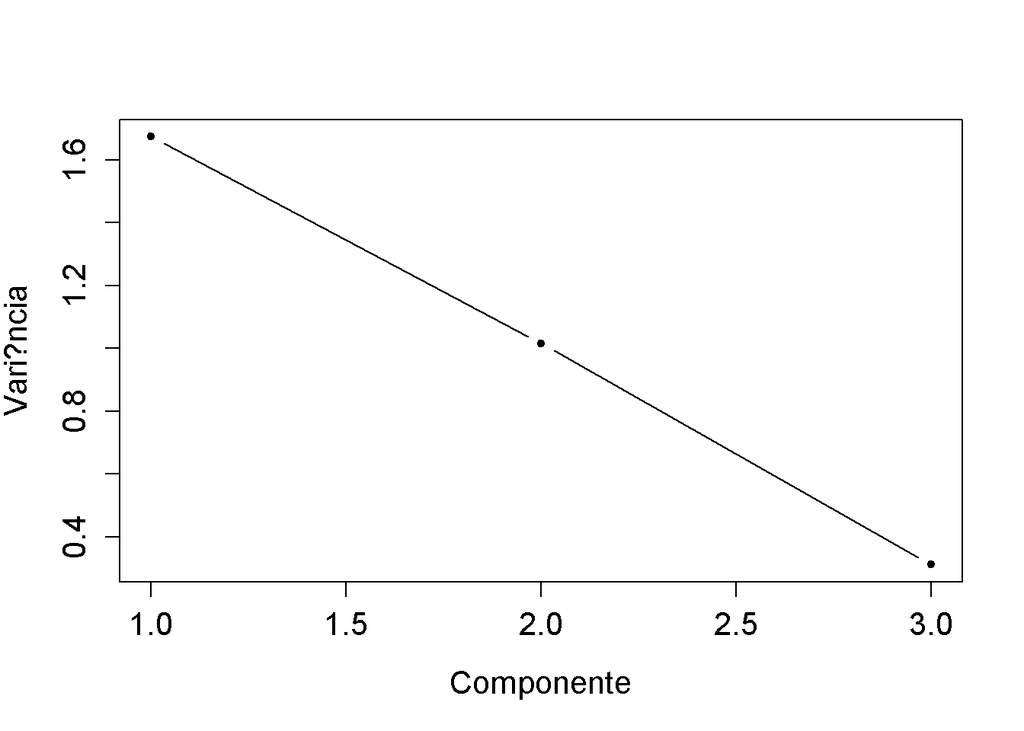

```r
plot(1:ncol(dados), acpcor$sdev^2, type = "b", xlab = "Componente",
     ylab = "Vari?ncia", pch = 20, cex.axis = 1.3, cex.lab = 1.3)
```

```r
#fatores
k <- 3
carfat <- acpcor$rotation[, 1:k] %*% diag(acpcor$sdev[1:k])
colnames(carfat) <- paste("Fator", 1:k, sep = " ")
carfat
```

```
##           Fator 1     Fator 2    Fator 3
## ERECTED 0.9193411  0.03465066 -0.3919327
## LENGTH  0.2350757  0.96342503  0.1286530
## LANES   0.8789792 -0.29390187  0.3755227
```

```r
#estimação das comunalidades e das variâncias específicas
comum <- rowSums(carfat^2)
vespec <- diag(matriz_correlacao) - comum
estimat <- cbind(comum, vespec, diag(matriz_correlacao))
rownames(estimat) <- colnames(dados)
colnames(estimat) <- c("Comunalidade", "Vari?ncia ?nica", "Vari?ncia")
estimat
```

```
##         Comunalidade Vari?ncia ?nica Vari?ncia
## ERECTED            1   -4.440892e-16         1
## LENGTH             1    0.000000e+00         1
## LANES              1    2.220446e-16         1
```

```r
resid <- matriz_correlacao - (carfat %*% t(carfat) + diag(vespec))
resid
```

```
##               ERECTED        LENGTH         LANES
## ERECTED  0.000000e+00 -3.330669e-16 -4.440892e-16
## LENGTH  -3.330669e-16  0.000000e+00 -1.838807e-16
## LANES   -4.440892e-16 -1.838807e-16  1.110223e-16
```

```r
#Visando auxiliar na interpretação dos fatores, realizamos uma rotação pelo método varimax.
#A função varimax encontra-se no pacote stats.

carfatr <- varimax(carfat)
carfatr
```

```
## $loadings
##
## Loadings:
##         Fator 1 Fator 2 Fator 3
## ERECTED  0.926   0.119   0.358
## LENGTH           0.995
## LANES    0.346           0.938
##
##                Fator 1 Fator 2 Fator 3
## SS loadings      0.987   1.006   1.008
## Proportion Var   0.329   0.335   0.336
## Cumulative Var   0.329   0.664   1.000
##
## $rotmat
##             [,1]      [,2]       [,3]
## [1,]  0.70418142 0.1847068  0.6855742
## [2,]  0.02358219 0.9589531 -0.2825825
## [3,] -0.70962836 0.2151567  0.6709212
```

Mesmo que a análise deva ser ignorada, podemos utilizar de algumas conclusões que essa análise pode fazer. A partir das informações acimas, podemos verificar que ERECTED foi a variável escolhida como a mais influenciadora, já que no primeiro fator. O que, mesmo sendo uma análise imprecisa, ainda confirma aquilo que já foi analisado anteriormente. E podemos prosseguir com a mesma linha de raciocínio para outras análises restantes.

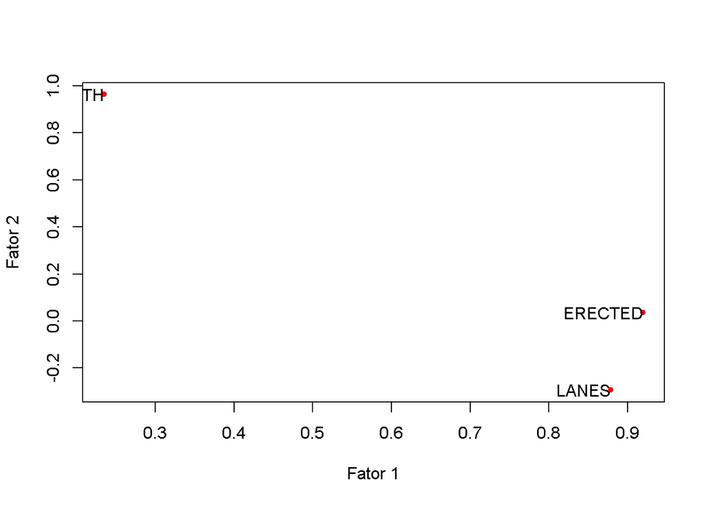

```r
#Plot sem rotação varimax
plot(carfat, pch = 20, col = "red", xlab = "Fator 1", ylab = "Fator 2")
text(carfat, rownames(carfat), adj = 1)
```

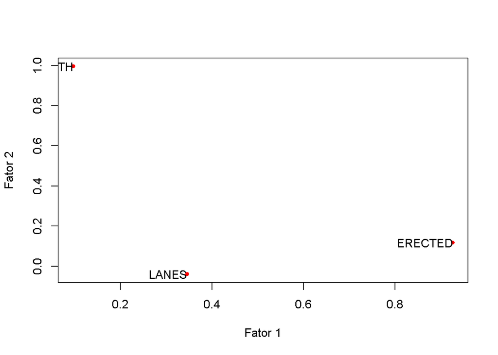

```r
#Plot com rotação varimax
plot(carfatr$loadings, pch = 20, col = "red", xlab = "Fator 1", ylab = "Fator 2")
text(carfatr$loadings, rownames(carfat), adj = 1)
```

## Escalonamento Multidimensional

```r
### Classical MDS
# N rows (objects) x p columns (variables)
# each row identified by a unique row name

data <- read.csv("data.txt", na.strings="?")
data <- data[complete.cases(data), ]
rownames(data) <- data[, 1]
mydata<- subset(data, select = c("LOCATION"))
d <- dist(mydata) # euclidean distances between the rows
fit <- cmdscale(d,eig=TRUE, k=2) # k is the number of dim
fit # view results
```

```
## $points
##              [,1]          [,2]
## E2      0.4385714  0.000000e+00
## E5     -3.5614286 -6.607876e-10
## E7     -1.5614286  2.322957e-07
## E8     -2.5614286  4.344741e-08
## E9     22.4385714  6.110835e-08
## E11    -3.5614286 -2.501708e-07
## E14    19.4385714  9.372724e-08
## E16     0.4385714 -1.038222e-07
## E18    -2.5614286  3.430793e-07
## E19    -3.5614286  6.939930e-08
## E20    -6.5614286  2.349516e-07
## E22     1.4385714  2.624938e-07
## E26    13.4385714  1.281910e-07
## E28    22.4385714  2.086003e-07
## E31    17.4385714 -1.808524e-07
## E34   -15.5614286  1.523094e-07
## E35    -1.5614286 -5.000742e-08
## E37     7.4385714  2.863315e-07
## E4     -1.5614286 -3.311114e-07
## E42    16.4385714 -2.915252e-08
## E43    18.4385714  9.595232e-08
## E46   -11.5614286  1.222447e-07
## E47    10.4385714  2.028884e-07
## E58    -7.5614286 -1.135394e-06
## E48   -12.5614286 -1.276715e-06
## E49    -8.5614286  7.950536e-08
## E95     9.4385714  2.264968e-07
## E87    -9.5614286  6.931950e-08
## E51    19.4385714 -1.631490e-07
## E89    21.4385714  3.520115e-09
## E53    -2.5614286  3.095714e-08
## E55   -10.5614286  6.431737e-08
## E57   -23.5614286  2.627115e-07
## E59   -17.5614286  2.447131e-07
## E61   -15.5614286  2.268692e-07
## E60     1.4385714  2.002798e-08
## E62   -11.5614286 -2.594105e-07
## E63    -5.5614286 -2.123996e-08
```

[output cut: 42 more lines]

[output not shown]

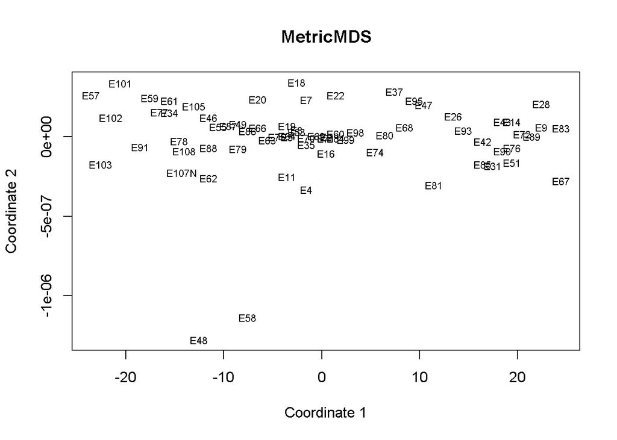

```r
# plot solution
x <- fit$points[,1]
y <- fit$points[,2]
plot(x, y, xlab="Coordinate 1", ylab="Coordinate 2",
     main="Metric   MDS",   type="n")
text(x, y, labels = row.names(mydata), cex=.7)
```

Apesar de haver um mapa das localizações das pontes, uma variável que não relaciona um dado com outro dado, ou seja, fornece uma relação de distância entre elas, não é capaz de formar um gráfico de distâncias entre as variáveis, o que é o principal propósito da análise de Escalonamento Multidimensional. Pelo gráfico dado acima, cada ponto (x,y) se baseou na categoria localização de 1 a 52 fornecida pela variável LOCATION, e não representa uma relação entre esses dados. Logo, essa análise é inválida, uma vez que não há informações disponíveis para o uso apropriado dessa técnica.